# Sparkify Project Workspace

This workspace contains a tiny subset (128MB) of the full dataset available (12GB). Feel free to use this workspace to build your project, or to explore a smaller subset with Spark before deploying your cluster on the cloud. Instructions for setting up your Spark cluster is included in the last lesson of the Extracurricular Spark Course content.

You can follow the steps below to guide your data analysis and model building portion of this project.

```python
! pip install pyspark_dist_explore
```

```python
# import libraries
from pyspark.sql import SparkSession
from pyspark.sql.types import StringType, IntegerType, StructType, StructField
from pyspark.sql.functions import desc, asc, udf, col, isnan, count, when, col, desc, col, sort_array, avg, max, format_string
from pyspark.sql.functions import sum as Fsum
from pyspark.sql import Window
from pyspark.ml.tuning import CrossValidator, ParamGridBuilder
from pyspark.ml.regression import LinearRegression
from pyspark_dist_explore import hist
from pyspark.sql import SQLContext

import datetime

import numpy as np
import pandas as pd
import matplotlib.pyplot as plt
%matplotlib inline
```

```python
# create a Spark session
spark = SparkSession \
    .builder \
    .appName("Sparkify Project") \
    .getOrCreate()
```

# Load and Clean Dataset

In this workspace, the mini-dataset file is `mini_sparkify_event_data.json`. Load and clean the dataset, checking for invalid or missing data - for example, records without userids or sessionids.

```python
sparkify_event_data = 'mini_sparkify_event_data.json'
df = spark.read.json(sparkify_event_data)
df.persist()
```

```
DataFrame[artist: string, auth: string, firstName: string, gender: string, itemInSession: bigint, lastName: string, length: double, level: string, location: string, method: string, page: string, registration: bigint, sessionId: bigint, song: string, status: bigint, ts: bigint, userAgent: string, use…
```

In Order to clean the data set, we need to take a closer look at the counts of the columns.

```python
"The dataset has {} entries.".format(df.count())
```

```
'The dataset has 286500 entries.'
```

```python
description = df.describe()
description.toPandas()
```

|  | summary | artist | auth | firstName | gender | itemInSession | lastName | length | level | location | method | page | registration | sessionId | song | status | ts | userAgent | userId |
| --- | --- | --- | --- | --- | --- | --- | --- | --- | --- | --- | --- | --- | --- | --- | --- | --- | --- | --- | --- |
| 0 | count | 228108 | 286500 | 278154 | 278154 | 286500 | 278154 | 228108 | 286500 | 278154 | 286500 | 286500 | 278154 | 286500 | 228108 | 286500 | 286500 | 278154 | 286500 |
| 1 | mean | 551.0852017937219 | None | None | None | 114.41421291448516 | None | 249.11718197783583 | None | None | None | None | 1.5353588340856191E12 | 1041.526554973822 | Infinity | 210.05459685863875 | 1.5409568898103945E12 | None | 59682.02278593872 |
| 2 | stddev | 1217.7693079161377 | None | None | None | 129.7672620114106 | None | 99.23517921058313 | None | None | None | None | 3.2913216163281236E9 | 726.7762634630807 | NaN | 31.505078488421987 | 1.50754396082106E9 | None | 109091.94999910559 |
| 3 | min | !!! | Cancelled | Adelaida | F | 0 | Adams | 0.78322 | free | Albany, OR | GET | About | 1521380675000 | 1 | Ãg Ãtti GrÃ¡a Ãsku | 200 | 1538352117000 | "Mozilla/5.0 (Macintosh; Intel Mac OS X 10_10)... |  |
| 4 | max | Ãlafur Arnalds | Logged Out | Zyonna | M | 1321 | Wright | 3024.66567 | paid | Winston-Salem, NC | PUT | Upgrade | 1543247354000 | 2474 | Ãau hafa sloppiÃ° undan Ã¾unga myrkursins | 404 | 1543799476000 | Mozilla/5.0 (compatible; MSIE 9.0; Windows NT ... | 99 |

```python
description.show(1, vertical=True)
```

```
-RECORD 0---------------
 summary       | count
 artist        | 228108
 auth          | 286500
 firstName     | 278154
 gender        | 278154
 itemInSession | 286500
 lastName      | 278154
 length        | 228108
 level         | 286500
 location      | 278154
 method        | 286500
 page          | 286500
 registration  | 278154
 sessionId     | 286500
 song          | 228108
 status        | 286500
 ts            | 286500
 userAgent     | 278154
 userId        | 286500
only showing top 1 row
```

The columns `firstName`, `gender`, `lastName`, `location`, `registration` and `userAgent` have the same count, so let's look at these rows first. We can see that the `userId` contains an empty string for these rows. Therefore, we can assume that these rows belong to users that are not logged in (column `auth` shows 'Logged out' as well). The distinct `page` values for these events support our hypothesis. We can drop these rows as our goal is to predict user churn behaviour and we can not link these pagevies / events to userIds.

```python
df.where(col('gender') \
         .isNull()) \
         .show(5)
```

```
+------+----------+---------+------+-------------+--------+------+-----+--------+------+-----+------------+---------+----+------+-------------+---------+------+
|artist|      auth|firstName|gender|itemInSession|lastName|length|level|location|method| page|registration|sessionId|song|status|           ts|userAgent|userId|
+------+----------+---------+------+-------------+--------+------+-----+--------+------+-----+------------+---------+----+------+-------------+---------+------+
|  null|Logged Out|     null|  null|          100|    null|  null| free|    null|   GET| Home|        null|        8|null|   200|1538355745000|     null|      |
|  null|Logged Out|     null|  null|          101|    null|  null| free|    null|   GET| Help|        null|        8|null|   200|1538355807000|     null|      |
|  null|Logged Out|     null|  null|          102|    null|  null| free|    null|   GET| Home|        null|        8|null|   200|1538355841000|     null|      |
|  null|Logged Out|     null|  null|          103|    null|  null| free|    null|   PUT|Login|        null|        8|null|   307|1538355842000|     null|      |
|  null|Logged Out|     null|  null|            2|    null|  null| free|    null|   GET| Home|        null|      240|null|   200|1538356678000|     null|      |
+------+----------+---------+------+-------------+--------+------+-----+--------+------+-----+------------+---------+----+------+-------------+---------+------+
only showing top 5 rows
```

```python
df.select('page').where(col('gender') \
         .isNull()) \
         .dropDuplicates() \
         .show(10)
```

```
+-------------------+
|               page|
+-------------------+
|               Home|
|              About|
|Submit Registration|
|              Login|
|           Register|
|               Help|
|              Error|
+-------------------+
```

```python
df_cleaned = df.dropna(how = 'any', subset = ['gender'])
diff = df.count()-df_cleaned.count()
df.count(), df_cleaned.count()
```

```
(286500, 278154)
```

```python
description_cl = df_cleaned.describe()
description_cl.show(1, vertical=True)
```

```
-RECORD 0---------------
 summary       | count
 artist        | 228108
 auth          | 278154
 firstName     | 278154
 gender        | 278154
 itemInSession | 278154
 lastName      | 278154
 length        | 228108
 level         | 278154
 location      | 278154
 method        | 278154
 page          | 278154
 registration  | 278154
 sessionId     | 278154
 song          | 228108
 status        | 278154
 ts            | 278154
 userAgent     | 278154
 userId        | 278154
only showing top 1 row
```

```python
"{} entries were dropped from the original dataframe.".format(diff)
```

```
'8346 entries were dropped from the original dataframe.'
```

Now we still have 3 columns with around 50,000 missing values: `artist`, `length` and `song`. When we look at the rows and especially the `page` values, we see that the column values are Null on all pages for logged-in users except 'Next Song'. We can keep these rows as the columns generally provide information regarding the songs played on the Sparkify App. Therefore, the values are Null if a user is not selecting a song on 'Next Song' page or navigates to any other administrative page. However, we might get usefull features out of it for our model. So we are ready to move on to exploratory analysis.

```python
df.where(col('artist') \
         .isNull()) \
         .show(5)
```

```
+------+---------+---------+------+-------------+--------+------+-----+--------------------+------+---------------+-------------+---------+----+------+-------------+--------------------+------+
|artist|     auth|firstName|gender|itemInSession|lastName|length|level|            location|method|           page| registration|sessionId|song|status|           ts|           userAgent|userId|
+------+---------+---------+------+-------------+--------+------+-----+--------------------+------+---------------+-------------+---------+----+------+-------------+--------------------+------+
|  null|Logged In|    Colin|     M|           54| Freeman|  null| paid|     Bakersfield, CA|   PUT|Add to Playlist|1538173362000|       29|null|   200|1538352905000|Mozilla/5.0 (Wind...|    30|
|  null|Logged In|    Micah|     M|           84|    Long|  null| free|Boston-Cambridge-...|   GET|    Roll Advert|1538331630000|        8|null|   200|1538353150000|"Mozilla/5.0 (Win...|     9|
|  null|Logged In|    Micah|     M|           86|    Long|  null| free|Boston-Cambridge-...|   PUT|      Thumbs Up|1538331630000|        8|null|   307|1538353376000|"Mozilla/5.0 (Win...|     9|
|  null|Logged In|    Alexi|     F|            4|  Warren|  null| paid|Spokane-Spokane V...|   GET|      Downgrade|1532482662000|       53|null|   200|1538354749000|Mozilla/5.0 (Wind...|    54|
|  null|Logged In|    Alexi|     F|            7|  Warren|  null| paid|Spokane-Spokane V...|   PUT|      Thumbs Up|1532482662000|       53|null|   307|1538355255000|Mozilla/5.0 (Wind...|    54|
+------+---------+---------+------+-------------+--------+------+-----+--------------------+------+---------------+-------------+---------+----+------+-------------+--------------------+------+
only showing top 5 rows
```

```python
df.select('page').where(col('artist') \
         .isNull()) \
         .distinct() \
         .show(50, False)
```

```
+-------------------------+
|page                     |
+-------------------------+
|Cancel                   |
|Submit Downgrade         |
|Thumbs Down              |
|Home                     |
|Downgrade                |
|Roll Advert              |
|Logout                   |
|Save Settings            |
|Cancellation Confirmation|
|About                    |
|Submit Registration      |
|Settings                 |
|Login                    |
|Register                 |
|Add to Playlist          |
|Add Friend               |
|Thumbs Up                |
|Help                     |
|Upgrade                  |
|Error                    |
|Submit Upgrade           |
+-------------------------+
```

```python
df.select('page').where(col('artist') \
         .isNotNull()) \
         .distinct() \
         .show(2)
```

```
+--------+
|    page|
+--------+
|NextSong|
+--------+
```

# Exploratory Data Analysis

When you're working with the full dataset, perform EDA by loading a small subset of the data and doing basic manipulations within Spark. In this workspace, you are already provided a small subset of data you can explore.

First, let's take a look at the schema to get familiar with the data set, its columns and data types.

```python
df_cleaned.printSchema()
```

```
root
 |-- artist: string (nullable = true)
 |-- auth: string (nullable = true)
 |-- firstName: string (nullable = true)
 |-- gender: string (nullable = true)
 |-- itemInSession: long (nullable = true)
 |-- lastName: string (nullable = true)
 |-- length: double (nullable = true)
 |-- level: string (nullable = true)
 |-- location: string (nullable = true)
 |-- method: string (nullable = true)
 |-- page: string (nullable = true)
 |-- registration: long (nullable = true)
 |-- sessionId: long (nullable = true)
 |-- song: string (nullable = true)
 |-- status: long (nullable = true)
 |-- ts: long (nullable = true)
 |-- userAgent: string (nullable = true)
 |-- userId: string (nullable = true)
```

```python
# diplay 2 rows
df_cleaned.take(2)
```

```
[Row(artist='Martha Tilston', auth='Logged In', firstName='Colin', gender='M', itemInSession=50, lastName='Freeman', length=277.89016, level='paid', location='Bakersfield, CA', method='PUT', page='NextSong', registration=1538173362000, sessionId=29, song='Rockpools', status=200, ts=1538352117000, us…
 Row(artist='Five Iron Frenzy', auth='Logged In', firstName='Micah', gender='M', itemInSession=79, lastName='Long', length=236.09424, level='free', location='Boston-Cambridge-Newton, MA-NH', method='PUT', page='NextSong', registration=1538331630000, sessionId=8, song='Canada', status=200, ts=1538352…
```

```python
# show as pandas dataframe for better visibility
df_cleaned.limit(3).toPandas()
```

|  | artist | auth | firstName | gender | itemInSession | lastName | length | level | location | method | page | registration | sessionId | song | status | ts | userAgent | userId |
| --- | --- | --- | --- | --- | --- | --- | --- | --- | --- | --- | --- | --- | --- | --- | --- | --- | --- | --- |
| 0 | Martha Tilston | Logged In | Colin | M | 50 | Freeman | 277.89016 | paid | Bakersfield, CA | PUT | NextSong | 1538173362000 | 29 | Rockpools | 200 | 1538352117000 | Mozilla/5.0 (Windows NT 6.1; WOW64; rv:31.0) G... | 30 |
| 1 | Five Iron Frenzy | Logged In | Micah | M | 79 | Long | 236.09424 | free | Boston-Cambridge-Newton, MA-NH | PUT | NextSong | 1538331630000 | 8 | Canada | 200 | 1538352180000 | "Mozilla/5.0 (Windows NT 6.1; WOW64) AppleWebK... | 9 |
| 2 | Adam Lambert | Logged In | Colin | M | 51 | Freeman | 282.82730 | paid | Bakersfield, CA | PUT | NextSong | 1538173362000 | 29 | Time For Miracles | 200 | 1538352394000 | Mozilla/5.0 (Windows NT 6.1; WOW64; rv:31.0) G... | 30 |

Let's look at each column and its possible values.

```python
# artist
df_cleaned.select('artist').distinct().count()
```

```
17656
```

```python
# auth
# 2 values, Logged out was dropped before
# 'Cancelled' appear only on 'Cancellation Confirmation' pages
# we don't really need this for feature engineering when we derive a feature from the page value
print(df_cleaned.select('auth').distinct().show())
df_cleaned.select('page','auth').where(col('auth') == 'Cancelled').distinct().show(1,False)
```

```
+---------+
|     auth|
+---------+
|Cancelled|
|Logged In|
+---------+

None
+-------------------------+---------+
|page                     |auth     |
+-------------------------+---------+
|Cancellation Confirmation|Cancelled|
+-------------------------+---------+
```

```python
# firstName
# skip
```

```python
# gender
df_cleaned.select('gender').distinct().show()
```

```
+------+
|gender|
+------+
|     F|
|     M|
+------+
```

```python
# itemInSession
# count of played songs in session
df_cleaned.select('itemInSession').distinct().sort('itemInSession', ascending=False).show(3)
```

```
+-------------+
|itemInSession|
+-------------+
|         1321|
|         1320|
|         1319|
+-------------+
only showing top 3 rows
```

```python
df_cleaned.select(['userId', 'ts', 'page', 'level', \
                   'itemInSession', 'song']) \
            .where(df_cleaned.userId == 32) \
            .sort("ts") \
            .toPandas().iloc[:3,]
```

|  | userId | ts | page | level | itemInSession | song |
| --- | --- | --- | --- | --- | --- | --- |
| 0 | 32 | 1538578897000 | NextSong | free | 0 | Beyond The Beyond (Instrumental) |
| 1 | 32 | 1538579134000 | NextSong | free | 1 | Paradise City |
| 2 | 32 | 1538579540000 | NextSong | free | 2 | Alejandro |

```python
# lastName
# skip
```

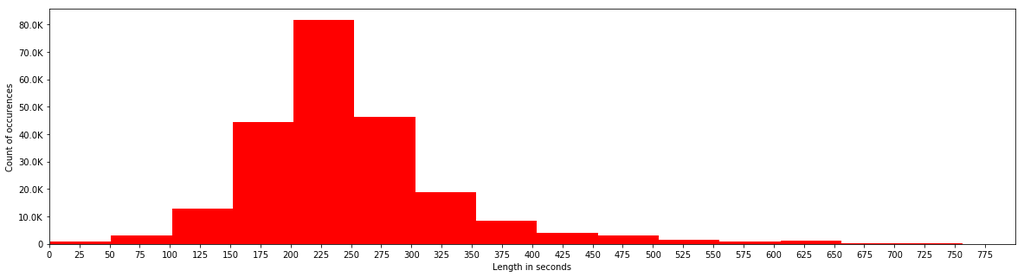

```python
# length
# majority of songs in range of 150 to 300 seconds
fig, ax = plt.subplots(figsize=(20,5))
hist(ax, df_cleaned.select('length').where(col('length').isNotNull()), bins = 60, color=['red']);
plt.xlabel('Length in seconds');
plt.ylabel('Count of occurences');
plt.xlim([0, 800]);
plt.xticks(np.arange(0,800, 25));
```

```python
# level
df_cleaned.select('level').distinct().show()
```

```
+-----+
|level|
+-----+
| free|
| paid|
+-----+
```

```python
# location
print("Number of locations in dataset: {}.".format(df_cleaned.select('location').distinct().count()))
df_cleaned.select('location').distinct().show(4)
```

```
Number of locations in dataset: 114.
+--------------------+
|            location|
+--------------------+
|     Gainesville, FL|
|Atlantic City-Ham...|
|Deltona-Daytona B...|
|San Diego-Carlsba...|
+--------------------+
only showing top 4 rows
```

```python
# method
df_cleaned.select('method').distinct().show(4)
```

```
+------+
|method|
+------+
|   PUT|
|   GET|
+------+
```

```python
# page
df_cleaned.select('page').distinct().sort('page').show(20, False)
```

```
+-------------------------+
|page                     |
+-------------------------+
|About                    |
|Add Friend               |
|Add to Playlist          |
|Cancel                   |
|Cancellation Confirmation|
|Downgrade                |
|Error                    |
|Help                     |
|Home                     |
|Logout                   |
|NextSong                 |
|Roll Advert              |
|Save Settings            |
|Settings                 |
|Submit Downgrade         |
|Submit Upgrade           |
|Thumbs Down              |
|Thumbs Up                |
|Upgrade                  |
+-------------------------+
```

```python
# distribution of page counts
df_cleaned.groupby('page').count().sort('count', ascending=False).show(20, False)
```

```
+-------------------------+------+
|page                     |count |
+-------------------------+------+
|NextSong                 |228108|
|Thumbs Up                |12551 |
|Home                     |10082 |
|Add to Playlist          |6526  |
|Add Friend               |4277  |
|Roll Advert              |3933  |
|Logout                   |3226  |
|Thumbs Down              |2546  |
|Downgrade                |2055  |
|Settings                 |1514  |
|Help                     |1454  |
|Upgrade                  |499   |
|About                    |495   |
|Save Settings            |310   |
|Error                    |252   |
|Submit Upgrade           |159   |
|Submit Downgrade         |63    |
|Cancel                   |52    |
|Cancellation Confirmation|52    |
+-------------------------+------+
```

```python
# registration
# unix epoch time in milliseconds, ts of registration
"Number of registration timestamps is surprisingly low, but matches count of userIds: {}.".format(df_cleaned.select('registration').distinct().count())
```

```
'Number of registration timestamps is surprisingly low, but matches count of userIds: 225.'
```

```python
# sessionId
df_cleaned.select('userId', 'sessionId').distinct().groupby('userId').count().sort('count', ascending=False).show(5)
```

```
+------+-----+
|userId|count|
+------+-----+
|    39|  107|
|    92|   86|
|300011|   76|
|200023|   76|
|   140|   71|
+------+-----+
only showing top 5 rows
```

```python
# song
print("Number of distinct songs: {}.".format(df_cleaned.select('song').distinct().count()))
df_cleaned\
        .select("userId", 'ts', 'song', 'artist')\
        .where(col('song').isNotNull())\
        .groupby('userId', 'song', 'artist')\
        .count()\
        .sort('count', ascending=False)\
        .show(5)
```

```
Number of distinct songs: 58481.
+------+--------------+-------------+-----+
|userId|          song|       artist|count|
+------+--------------+-------------+-----+
|    39|          Undo|     BjÃÂ¶rk|   38|
|    39|You're The One|Dwight Yoakam|   28|
|   140|       Revelry|Kings Of Leon|   26|
|300011|You're The One|Dwight Yoakam|   26|
|300017|       Revelry|Kings Of Leon|   25|
+------+--------------+-------------+-----+
only showing top 5 rows
```

```python
# status
df_cleaned.groupby('status').count().sort('count', ascending=False).show()
```

```
+------+------+
|status| count|
+------+------+
|   200|254718|
|   307| 23184|
|   404|   252|
+------+------+
```

```python
# ts
# unix epoch time in milliseconds, ts of the event
```

```python
# userAgent
# 56 different values, lets see if there's a trend for comparison of churned / active users
df_cleaned.select('userAgent').distinct().sort('userAgent').show(5, False)
```

```
+--------------------------------------------------------------------------------------------------------------------------+
|userAgent                                                                                                                 |
+--------------------------------------------------------------------------------------------------------------------------+
|"Mozilla/5.0 (Macintosh; Intel Mac OS X 10_10) AppleWebKit/600.1.3 (KHTML, like Gecko) Version/8.0 Safari/600.1.3"        |
|"Mozilla/5.0 (Macintosh; Intel Mac OS X 10_10) AppleWebKit/600.1.8 (KHTML, like Gecko) Version/8.0 Safari/600.1.8"        |
|"Mozilla/5.0 (Macintosh; Intel Mac OS X 10_6_8) AppleWebKit/537.36 (KHTML, like Gecko) Chrome/36.0.1985.143 Safari/537.36"|
|"Mozilla/5.0 (Macintosh; Intel Mac OS X 10_7_5) AppleWebKit/537.36 (KHTML, like Gecko) Chrome/36.0.1985.125 Safari/537.36"|
|"Mozilla/5.0 (Macintosh; Intel Mac OS X 10_7_5) AppleWebKit/537.77.4 (KHTML, like Gecko) Version/6.1.5 Safari/537.77.4"   |
+--------------------------------------------------------------------------------------------------------------------------+
only showing top 5 rows
```

```python
# userId
df_cleaned.select('userId').distinct().count()
```

```
225
```

### Define Churn

Once you've done some preliminary analysis, create a column `Churn` to use as the label for your model. I suggest using the `Cancellation Confirmation` events to define your churn, which happen for both paid and free users. As a bonus task, you can also look into the `Downgrade` events.

It turned out that there might be 2 possible definitions of churn. One could be the downgrade from a paid subscription, the other one could be the actual cancelation of the account. The second one is actually worse because a user that canceled his account might never come back. As proposed we will take the `Cancellation Confirmation` page as label for our model. However, keeping the count of `Downgrade` and `Submit Downgrade` pages might be a useful feature for our model.

Apparently, customers check the `Downgrade` page more often than they eventually submit the downgrade. We have 52 cancellations in total and 63 downgrade submission. We could also observe that customers had `Downgrade` pageviews and no cancellation as well as a cancellation without looking at the `Downgrade` page previously.

```python
print(df_cleaned.filter("page = 'Downgrade'").count())
print(df_cleaned.filter("page = 'Submit Downgrade'").count())
print(df_cleaned.filter("page = 'Cancel'").count())
print(df_cleaned.filter("page = 'Cancellation Confirmation'").count())
```

```
2055
63
52
52
```

```python
# get a few userIds to check their count of 'Downgrade' pages
df_cleaned.select('userId', 'page').filter("page = 'Downgrade'").show(2)
```

```
+------+---------+
|userId|     page|
+------+---------+
|    54|Downgrade|
|    95|Downgrade|
+------+---------+
only showing top 2 rows
```

```python
print(df_cleaned.select('userId', 'page')\
    .where(((col('page') == 'Downgrade') | (col('page') == 'Cancellation Confirmation')) & (col('userId') == 54))\
    .groupby('userId', 'page')\
    .count()\
    .sort('userId')\
    .show(2, False))

df_cleaned.select('userId', 'page')\
    .where((col('page') == 'Downgrade') | (col('page') == 'Cancellation Confirmation'))\
    .groupby('userId', 'page')\
    .count()\
    .sort('userId')\
    .show(10, False)
```

```
+------+-------------------------+-----+
|userId|page                     |count|
+------+-------------------------+-----+
|54    |Downgrade                |39   |
|54    |Cancellation Confirmation|1    |
+------+-------------------------+-----+

None
+------+-------------------------+-----+
|userId|page                     |count|
+------+-------------------------+-----+
|10    |Downgrade                |7    |
|100   |Downgrade                |30   |
|100001|Cancellation Confirmation|1    |
|100002|Downgrade                |2    |
|100003|Cancellation Confirmation|1    |
|100004|Downgrade                |10   |
|100005|Cancellation Confirmation|1    |
|100006|Cancellation Confirmation|1    |
|100007|Downgrade                |7    |
|100007|Cancellation Confirmation|1    |
+------+-------------------------+-----+
only showing top 10 rows
```

```python
#create a column 'event_cancelation' to use as the label for your model
tag_event_cancelation = udf(lambda x: 1 if x == 'Cancellation Confirmation' else 0, IntegerType())
df_cleaned = df_cleaned.withColumn('event_cancelation', tag_event_cancelation(df_cleaned["page"]))
```

```python
# check if function worked
print(df_cleaned.filter("page = 'Cancellation Confirmation'").head())
df_cleaned.head()
```

```
Row(artist=None, auth='Cancelled', firstName='Adriel', gender='M', itemInSession=104, lastName='Mendoza', length=None, level='paid', location='Kansas City, MO-KS', method='GET', page='Cancellation Confirmation', registration=1535623466000, sessionId=514, song=None, status=200, ts=1538943990000, user…
```

```
Row(artist='Martha Tilston', auth='Logged In', firstName='Colin', gender='M', itemInSession=50, lastName='Freeman', length=277.89016, level='paid', location='Bakersfield, CA', method='PUT', page='NextSong', registration=1538173362000, sessionId=29, song='Rockpools', status=200, ts=1538352117000, use…
```

```python
# window for tagging churned user
windowval = Window.partitionBy("userId")
```

```python
df_cleaned = df_cleaned.withColumn('user_canceled', Fsum('event_cancelation').over(windowval))
df_cleaned.select('user_canceled').distinct().show()
```

```
+-------------+
|user_canceled|
+-------------+
|            0|
|            1|
+-------------+
```

```python
# find count of pages from churned user in order to check previous column additions
df_cleaned.groupBy("userId") \
    .agg({"page": "count", "event_cancelation": "sum"}) \
    .filter("sum(event_cancelation) > 0") \
    .sort("count(page)").show(12)
```

```
+------+-----------+----------------------+
|userId|count(page)|sum(event_cancelation)|
+------+-----------+----------------------+
|   125|         11|                     1|
|100011|         23|                     1|
|100024|         36|                     1|
|100006|         44|                     1|
|   122|         62|                     1|
|100017|         75|                     1|
|100003|         78|                     1|
|100019|         89|                     1|
|    32|        108|                     1|
|300007|        143|                     1|
|   143|        149|                     1|
|200001|        158|                     1|
+------+-----------+----------------------+
only showing top 12 rows
```

```python
df_cleaned.\
    select(["userId", "ts", "page", "level", "event_cancelation", "user_canceled"]) \
    .where(df_cleaned.userId == 100011).sort("ts") \
    .toPandas()
```

|  | userId | ts | page | level | event_cancelation | user_canceled |
| --- | --- | --- | --- | --- | --- | --- |
| 0 | 100011 | 1538414422000 | Home | free | 0 | 1 |
| 1 | 100011 | 1538414456000 | NextSong | free | 0 | 1 |
| 2 | 100011 | 1538414463000 | Home | free | 0 | 1 |
| 3 | 100011 | 1538414867000 | NextSong | free | 0 | 1 |
| 4 | 100011 | 1538414867000 | Roll Advert | free | 0 | 1 |
| 5 | 100011 | 1538415056000 | NextSong | free | 0 | 1 |
| 6 | 100011 | 1538415104000 | Home | free | 0 | 1 |
| 7 | 100011 | 1538415285000 | NextSong | free | 0 | 1 |
| 8 | 100011 | 1538415557000 | NextSong | free | 0 | 1 |
| 9 | 100011 | 1538415581000 | Roll Advert | free | 0 | 1 |
| 10 | 100011 | 1538415909000 | NextSong | free | 0 | 1 |
| 11 | 100011 | 1538415928000 | Add to Playlist | free | 0 | 1 |
| 12 | 100011 | 1538416150000 | NextSong | free | 0 | 1 |
| 13 | 100011 | 1538416415000 | NextSong | free | 0 | 1 |
| 14 | 100011 | 1538416419000 | Add to Playlist | free | 0 | 1 |
| 15 | 100011 | 1538416667000 | NextSong | free | 0 | 1 |
| 16 | 100011 | 1538416874000 | NextSong | free | 0 | 1 |
| 17 | 100011 | 1538416875000 | Settings | free | 0 | 1 |
| 18 | 100011 | 1538416899000 | Home | free | 0 | 1 |
| 19 | 100011 | 1538417062000 | NextSong | free | 0 | 1 |
| 20 | 100011 | 1538417063000 | Thumbs Down | free | 0 | 1 |
| 21 | 100011 | 1538417064000 | Cancel | free | 0 | 1 |
| 22 | 100011 | 1538417085000 | Cancellation Confirmation | free | 1 | 1 |

### Explore Data

Once you've defined churn, perform some exploratory data analysis to observe the behavior for users who stayed vs users who churned. You can start by exploring aggregates on these two groups of users, observing how much of a specific action they experienced per a certain time unit or number of songs played.

### 1. Count of churned vs non-churned users

```python
user_churn = df_cleaned.select('userId','user_canceled') \
                .distinct() \
                .groupBy('user_canceled') \
                .agg({'userId':'count'}) \
                .toPandas()
user_churn
```

|  | user_canceled | count(userId) |
| --- | --- | --- |
| 0 | 0 | 173 |
| 1 | 1 | 52 |

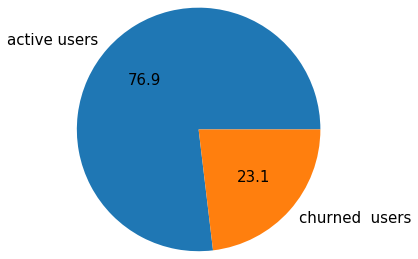

```python
data = user_churn.iloc[:,1]
labels = ['active users','churned  users']
plt.pie(data, labels=labels, radius=1.4, autopct='%.1f', textprops={'size': 15});
```

### 2. User groups divided by gender

```python
user_churn_gender = df_cleaned.select('userId', 'gender', 'user_canceled') \
                .distinct() \
                .groupBy('user_canceled','gender') \
                .agg({'userId':'count'}) \
                .sort('user_canceled','gender')

user_churn_gender.show()
user_churn_gender = user_churn_gender.toPandas()
```

```
+-------------+------+-------------+
|user_canceled|gender|count(userId)|
+-------------+------+-------------+
|            0|     F|           84|
|            0|     M|           89|
|            1|     F|           20|
|            1|     M|           32|
+-------------+------+-------------+
```

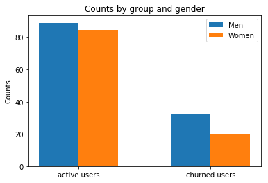

```python
men = user_churn_gender[user_churn_gender['gender']=='M'].iloc[:,2]
women = user_churn_gender[user_churn_gender['gender']=='F'].iloc[:,2]

ind = np.arange(len(men))  # the x locations for the groups
width = 0.3# the width of the bars

fig, ax = plt.subplots()
rects1 = ax.bar(ind - width/2, men, width, label='Men')
rects2 = ax.bar(ind + width/2, women, width, label='Women')

# Add some text for labels, title and custom x-axis tick labels, etc.
ax.set_ylabel('Counts')
ax.set_title('Counts by group and gender')
ax.set_xticks(ind)
ax.set_xticklabels(('active users', 'churned users'))
ax.legend();
```

### 3. avg. count of events per user between groups

```python
count_page_per_user = df_cleaned.select('userId','page','user_canceled') \
                                .groupby('userId','user_canceled') \
                                .agg({'page':'count'}) \
                                .sort('user_canceled','count(page)')
```

```python
count_page_per_user.groupby('user_canceled').agg({'count(page)':'avg'}).show()
```

```
+-------------+------------------+
|user_canceled|  avg(count(page))|
+-------------+------------------+
|            0|1348.4971098265896|
|            1| 862.7692307692307|
+-------------+------------------+
```

```python
events_active = count_page_per_user.where(col('user_canceled') == 0).toPandas()
events_churned = count_page_per_user.where(col('user_canceled') == 1).toPandas()
```

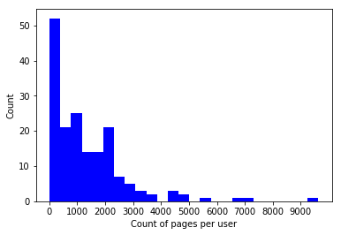

```python
plt.hist(events_active['count(page)'], bins=25, color=['blue']);
plt.xlabel('Count of pages per user');
plt.ylabel('Count');
plt.xticks(np.arange(0,10000, 1000));
```

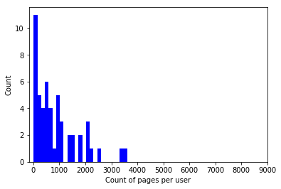

```python
plt.hist(events_churned['count(page)'], bins=25, color=['blue']);
plt.xlabel('Count of pages per user');
plt.ylabel('Count');
plt.xticks(np.arange(0,10000, 1000));
```

### 4. Distribution of lifetimes (max event ts since registraton ts) for both groups

```python
lt_df = df_cleaned.groupby('userId','user_canceled') \
            .agg({'registration' : 'min','ts':'max'})\
            .withColumn('lt_in_days',(col('max(ts)')-col('min(registration)'))/1000/60/60/24)

lt_df.show(10)
```

```
+------+-------------+-----------------+-------------+------------------+
|userId|user_canceled|min(registration)|      max(ts)|        lt_in_days|
+------+-------------+-----------------+-------------+------------------+
|100010|            0|    1538016340000|1542823952000| 55.64365740740741|
|200002|            0|    1536269906000|1542324354000| 70.07462962962963|
|   125|            1|    1533157139000|1539318918000| 71.31688657407408|
|   124|            0|    1532224335000|1543590766000|131.55591435185184|
|    51|            1|    1538080987000|1539761972000|19.455844907407407|
|     7|            0|    1536667576000|1542955611000| 72.77818287037037|
|    15|            0|    1538239045000|1543121818000|56.513576388888886|
|    54|            1|    1532482662000|1542051608000|110.75168981481481|
|   155|            0|    1541370470000|1543405710000|23.556018518518517|
|100014|            1|    1535389443000|1542740649000| 85.08340277777778|
+------+-------------+-----------------+-------------+------------------+
only showing top 10 rows
```

```python
# avg. lifetime per group
lt_df.select('user_canceled','lt_in_days').groupby('user_canceled').avg('lt_in_days').show()
```

```
+-------------+-----------------+
|user_canceled|  avg(lt_in_days)|
+-------------+-----------------+
|            0|86.62061938021834|
|            1|57.30599292200857|
+-------------+-----------------+
```

```python
# pandas df for plots
lt_df_pd = lt_df.toPandas()
```

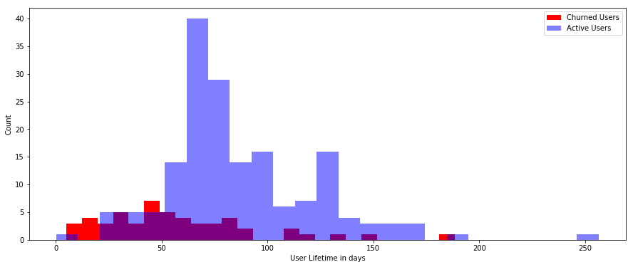

```python
y1 = lt_df_pd[lt_df_pd['user_canceled'] == 1]['lt_in_days']
y2 = lt_df_pd[lt_df_pd['user_canceled'] == 0]['lt_in_days']

#plots the histogram
fig, ax1 = plt.subplots(figsize=(15,6))
ax1.hist(y1, color='r', bins=25, alpha=1)
ax1.hist(y2, color='b', bins=25, alpha=0.5)
ax1.set_xlabel('User Lifetime in days');
ax1.set_ylabel('Count');
plt.xticks(np.arange(0,300, 50));
ax1.legend(loc='upper right',labels=['Churned Users','Active Users'])

plt.show()
```

### 5. Avg. count of songs listened per group (plus `page` dimension)

In order to find out the avg. number of songs listened by user group we can take the avg. count of 'NextSong' pageviews. We can also write a funtion to repeat this for all the other pages.

```python
# create list of pages
pages = [row[0] for row in df_cleaned.select('page').distinct().collect()]
print(pages)
```

```
['Cancel', 'Submit Downgrade', 'Thumbs Down', 'Home', 'Downgrade', 'Roll Advert', 'Logout', 'Save Settings', 'Cancellation Confirmation', 'About', 'Settings', 'Add to Playlist', 'Add Friend', 'NextSong', 'Thumbs Up', 'Help', 'Upgrade', 'Error', 'Submit Upgrade']
```

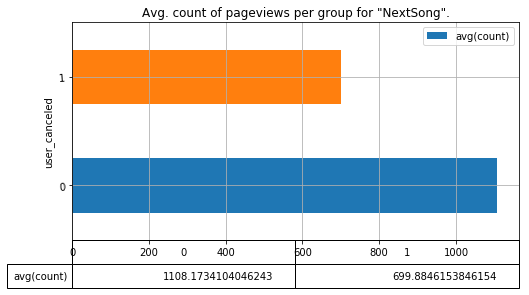

```python
plot = df_cleaned.where(df_cleaned.page == 'NextSong')\
        .groupby('userId','user_canceled')\
        .count()\
        .groupby('user_canceled')\
        .agg({'count':'avg'})\
        .toPandas()\
        .plot(x='user_canceled',y='avg(count)',kind='barh',
              title='Avg. count of pageviews per group for "{}".'.format('NextSong'),
             table=True, grid=True, figsize=(8,4), rot=4);
table = plot.tables[0]
# Setting the font size
table.set_fontsize(10)
# Rescaling the rows to be more readable
table.scale(1,2)
```

```python
def plot_avg_page_count(page):
    plot = df_cleaned.where(df_cleaned.page == page)\
        .groupby('userId','user_canceled')\
        .count()\
        .groupby('user_canceled')\
        .agg({'count':'avg'})\
        .toPandas()\
        .plot(x='user_canceled',y='avg(count)',kind='barh',
              title='Avg. count of pageviews per group for "{}".'.format(page),
             table=True, grid=True, figsize=(8,4), rot=4);
    table = plot.tables[0]
    table.set_fontsize(10) # Setting the font size
    table.scale(1,2) # Rescaling the rows to be more readable
```

```
Cell execution started 2019-06-04 11:55:19.046888
Cell execution ended 2019-06-04 11:59:39.927528
Wall time: 4min 20s
```

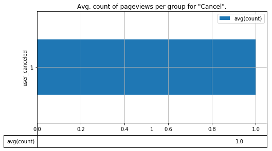

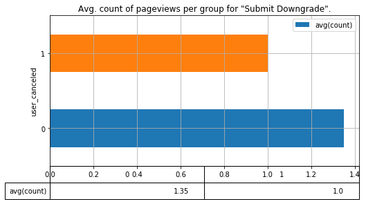

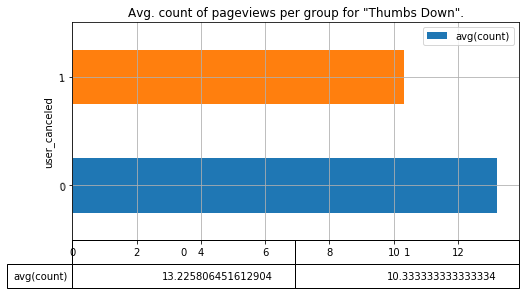

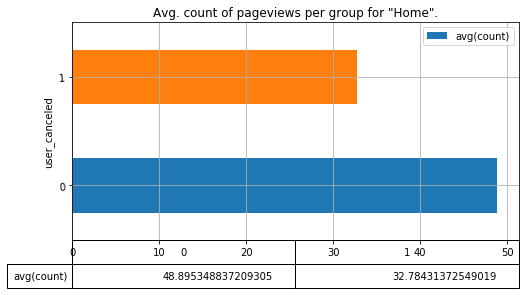

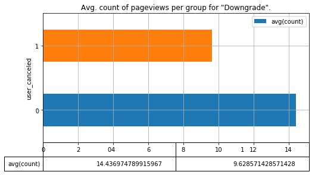

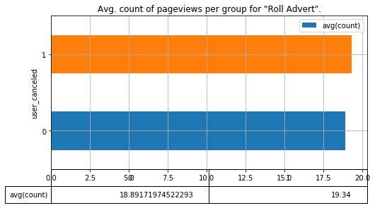

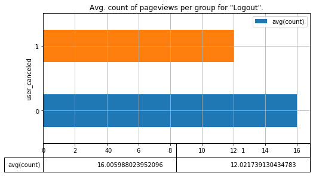

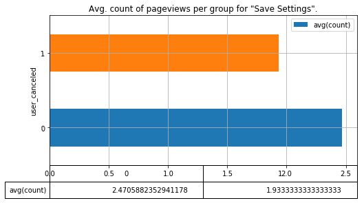

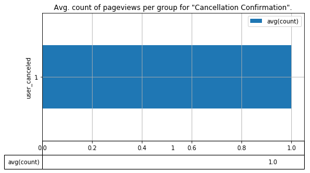

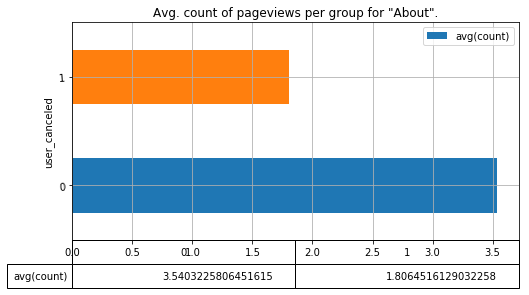

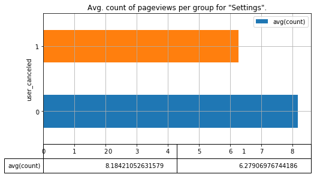

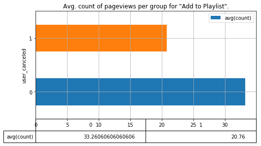

[7 more figures not shown]

```python
%%time
print('Cell execution started', datetime.datetime.now())
for page in pages:
    plot_avg_page_count(page)
print('Cell execution ended', datetime.datetime.now())
```

### 6. Avg. count of songs listened per session per group

```python
%%time
df_cleaned.select('userId', 'user_canceled', 'sessionId','itemInSession') \
            .groupby('userId', 'user_canceled', 'sessionId') \
            .agg({'itemInSession':'max'})\
            .groupby('userId', 'user_canceled')\
            .agg({'max(itemInSession)':'avg'})\
            .sort('userId')\
            .groupby('user_canceled')\
            .agg({'avg(max(itemInSession))':'avg'})\
            .withColumnRenamed('avg(avg(max(itemInSession)))','avg_count_songs_usersession')\
            .show()
```

```
+-------------+---------------------------+
|user_canceled|avg_count_songs_usersession|
+-------------+---------------------------+
|            0|          88.45245181871891|
|            1|          78.93743736837953|
+-------------+---------------------------+

Wall time: 21.9 s
```

```python
df_songs_pd = df_cleaned.select('userId', 'user_canceled', 'sessionId','itemInSession') \
            .groupby('userId', 'user_canceled', 'sessionId') \
            .agg({'itemInSession':'max'}) \
            .groupby('userId', 'user_canceled') \
            .agg({'max(itemInSession)':'avg'}) \
            .sort('userId') \
            .toPandas()
```

```python
df_songs_pd.head(2)
```

|  | userId | user_canceled | avg(max(itemInSession)) |
| --- | --- | --- | --- |
| 0 | 10 | 0 | 135.500000 |
| 1 | 100 | 0 | 93.228571 |

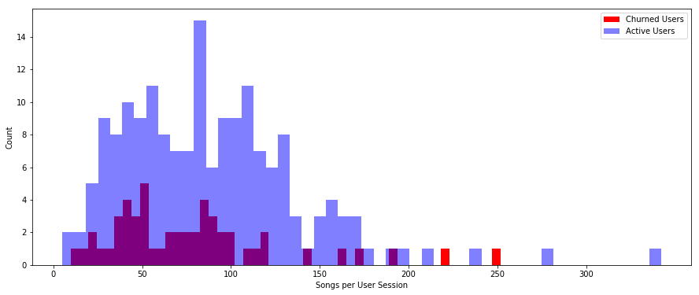

```python
y1 = df_songs_pd[df_songs_pd['user_canceled'] == 1]['avg(max(itemInSession))']
y2 = df_songs_pd[df_songs_pd['user_canceled'] == 0]['avg(max(itemInSession))']

#plots the histogram
fig, ax1 = plt.subplots(figsize=(15,6))
ax1.hist(y1, color='r', bins=50, alpha=1)
ax1.hist(y2, color='b', bins=50, alpha=0.5)
ax1.set_xlabel('Songs per User Session');
ax1.set_ylabel('Count');
plt.xticks(np.arange(0,350, 50));
ax1.legend(loc='upper right',labels=['Churned Users','Active Users'])

plt.show()
```

### 7. Subscription Level per group

```python
# we can see that some users had both levels
df_cleaned.select('userId','level').distinct()\
            .where((df_cleaned.userId == 100016) | (df_cleaned.userId == 100018))\
            .sort('userId').show(50)
```

```
+------+-----+
|userId|level|
+------+-----+
|100016| free|
|100016| paid|
|100018| free|
|100018| paid|
+------+-----+
```

```python
# for simplicity it might make sense to introduce a feature that indicates wheter a user ever had a paid account
#create a column 'event_cancelation' to use as the label for your model
tag_event_level_paid = udf(lambda x: 1 if x == 'paid' else 0, IntegerType())
df_cleaned = df_cleaned.withColumn('event_level_paid', tag_event_level_paid('level'))\
                        .withColumn('user_level_paid', max('event_level_paid').over(windowval))
df_cleaned.select('user_level_paid').distinct().show()
```

```
+---------------+
|user_level_paid|
+---------------+
|              1|
|              0|
+---------------+
```

```python
%%time
df_cleaned.select('userId', 'user_canceled', 'user_level_paid')\
        .distinct()\
        .groupby('user_canceled','user_level_paid')\
        .agg({'userId':'count'}).show()
```

```
+-------------+---------------+-------------+
|user_canceled|user_level_paid|count(userId)|
+-------------+---------------+-------------+
|            1|              1|           36|
|            0|              0|           44|
|            0|              1|          129|
|            1|              0|           16|
+-------------+---------------+-------------+

Wall time: 7min 19s
```

```python
%%time
df_level_pd = df_cleaned.select('userId', 'user_canceled', 'user_level_paid')\
                .distinct()\
                .toPandas()
```

```
Wall time: 5min 59s
```

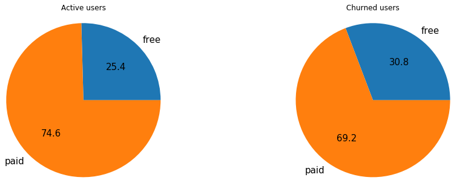

```python
data_0 = df_level_pd[df_level_pd['user_canceled']==0].groupby('user_level_paid')['userId'].count().values
labels_0 = ['free','paid']

data_1 = df_level_pd[df_level_pd['user_canceled']==1].groupby('user_level_paid')['userId'].count().values
labels_1 = ['free','paid']

fig, axs = plt.subplots(1, 2, figsize=(10,5))

axs[0].pie(data_0, labels=labels_0, radius=4, autopct='%.1f', textprops={'size': 15});
axs[1].pie(data_1, labels=labels_1, radius=4, autopct='%.1f', textprops={'size': 15});

axs[0].set_title('Active users', y=2.3)
axs[1].set_title('Churned users', y=2.3)

plt.subplots_adjust(wspace=5)

plt.show();
```